# video game analysis

Kashish Pandey

## Importing Libraries

```r
library(tidyverse)
```

```r
library(ggplot2)
library(tree)
library(caret)
library(elasticnet)
library(corrplot)
library(kernlab)
```

## EDA

na.strings is removing null/blank values within the dataset

```r
vg_sales <- read.csv("dataset/Video_Games_Sales_as_at_22_Dec_2016.csv",
                        sep=",",na.strings=c(""," ","NA","N/A"))
```

viewing the first 5 lines of the csv file

```r
head(vg_sales)
```

```
##                       Name Platform Year_of_Release        Genre Publisher
## 1               Wii Sports      Wii            2006       Sports  Nintendo
## 2        Super Mario Bros.      NES            1985     Platform  Nintendo
## 3           Mario Kart Wii      Wii            2008       Racing  Nintendo
## 4        Wii Sports Resort      Wii            2009       Sports  Nintendo
## 5 Pokemon Red/Pokemon Blue       GB            1996 Role-Playing  Nintendo
## 6                   Tetris       GB            1989       Puzzle  Nintendo
##   NA_Sales EU_Sales JP_Sales Other_Sales Global_Sales Critic_Score Critic_Count
## 1    41.36    28.96     3.77        8.45        82.53           76           51
## 2    29.08     3.58     6.81        0.77        40.24           NA           NA
## 3    15.68    12.76     3.79        3.29        35.52           82           73
## 4    15.61    10.93     3.28        2.95        32.77           80           73
## 5    11.27     8.89    10.22        1.00        31.37           NA           NA
## 6    23.20     2.26     4.22        0.58        30.26           NA           NA
##   User_Score User_Count Developer Rating
## 1        8.0        322  Nintendo      E
## 2         NA         NA      <NA>   <NA>
## 3        8.3        709  Nintendo      E
## 4        8.0        192  Nintendo      E
## 5         NA         NA      <NA>   <NA>
## 6         NA         NA      <NA>   <NA>
```

general summary of dataset

```r
# summary(vg_sales)
```

checking number of null values within the dataset

```r
colSums(is.na(vg_sales))
```

```
##            Name        Platform Year_of_Release           Genre       Publisher
##               2               0             269               2              54
##        NA_Sales        EU_Sales        JP_Sales     Other_Sales    Global_Sales
##               0               0               0               0               0
##    Critic_Score    Critic_Count      User_Score      User_Count       Developer
##            8582            8582            9129            9129            6623
##          Rating
##            6769
```

# dropping NA values from dataset

many missing values within this dataset

it is the combination of 2 different datasets and many of the original observations

did not match the data from the second set

```r
vg_sales <- vg_sales[complete.cases(vg_sales), ]
colSums(is.na(vg_sales))
```

```
##            Name        Platform Year_of_Release           Genre       Publisher
##               0               0               0               0               0
##        NA_Sales        EU_Sales        JP_Sales     Other_Sales    Global_Sales
##               0               0               0               0               0
##    Critic_Score    Critic_Count      User_Score      User_Count       Developer
##               0               0               0               0               0
##          Rating
##               0
```

getting internal structure of each feature

```r
str(vg_sales)
```

```
## 'data.frame':    6825 obs. of  16 variables:
##  $ Name           : chr  "Wii Sports" "Mario Kart Wii" "Wii Sports Resort" "New Super Mario Bros." ...
##  $ Platform       : chr  "Wii" "Wii" "Wii" "DS" ...
##  $ Year_of_Release: int  2006 2008 2009 2006 2006 2009 2005 2007 2010 2009 ...
##  $ Genre          : chr  "Sports" "Racing" "Sports" "Platform" ...
##  $ Publisher      : chr  "Nintendo" "Nintendo" "Nintendo" "Nintendo" ...
##  $ NA_Sales       : num  41.4 15.7 15.6 11.3 14 ...
##  $ EU_Sales       : num  28.96 12.76 10.93 9.14 9.18 ...
##  $ JP_Sales       : num  3.77 3.79 3.28 6.5 2.93 4.7 4.13 3.6 0.24 2.53 ...
##  $ Other_Sales    : num  8.45 3.29 2.95 2.88 2.84 2.24 1.9 2.15 1.69 1.77 ...
##  $ Global_Sales   : num  82.5 35.5 32.8 29.8 28.9 ...
##  $ Critic_Score   : int  76 82 80 89 58 87 91 80 61 80 ...
##  $ Critic_Count   : int  51 73 73 65 41 80 64 63 45 33 ...
##  $ User_Score     : num  8 8.3 8 8.5 6.6 8.4 8.6 7.7 6.3 7.4 ...
##  $ User_Count     : int  322 709 192 431 129 594 464 146 106 52 ...
##  $ Developer      : chr  "Nintendo" "Nintendo" "Nintendo" "Nintendo" ...
##  $ Rating         : chr  "E" "E" "E" "E" ...
```

examining outlier data for sales

```r
summary(vg_sales$NA_Sales)
```

```
##    Min. 1st Qu.  Median    Mean 3rd Qu.    Max.
##  0.0000  0.0600  0.1500  0.3945  0.3900 41.3600
```

```r
summary(vg_sales$EU_Sales)
```

```
##    Min. 1st Qu.  Median    Mean 3rd Qu.    Max.
##  0.0000  0.0200  0.0600  0.2361  0.2100 28.9600
```

```r
summary(vg_sales$JP_Sales)
```

```
##    Min. 1st Qu.  Median    Mean 3rd Qu.    Max.
## 0.00000 0.00000 0.00000 0.06416 0.01000 6.50000
```

```r
summary(vg_sales$Other_Sales)
```

```
##     Min.  1st Qu.   Median     Mean  3rd Qu.     Max.
##  0.00000  0.01000  0.02000  0.08268  0.07000 10.57000
```

```r
summary(vg_sales$Global_Sales)
```

```
##    Min. 1st Qu.  Median    Mean 3rd Qu.    Max.
##  0.0100  0.1100  0.2900  0.7776  0.7500 82.5300
```

examining outlier data for score/count

```r
summary(vg_sales$Critic_Score)
```

```
##    Min. 1st Qu.  Median    Mean 3rd Qu.    Max.
##   13.00   62.00   72.00   70.27   80.00   98.00
```

```r
summary(vg_sales$Critic_Count)
```

```
##    Min. 1st Qu.  Median    Mean 3rd Qu.    Max.
##    3.00   14.00   25.00   28.93   39.00  113.00
```

```r
summary(vg_sales$User_Count)
```

```
##    Min. 1st Qu.  Median    Mean 3rd Qu.    Max.
##     4.0    11.0    27.0   174.7    89.0 10665.0
```

```r
summary(vg_sales$User_Score)
```

```
##    Min. 1st Qu.  Median    Mean 3rd Qu.    Max.
##   0.500   6.500   7.500   7.186   8.200   9.600
```

# critic score is int and user score is num

changing user score to int to keep it consistent

```r
vg_sales$User_Score <- as.integer(vg_sales$User_Score)
summary(vg_sales$User_Score)
```

```
##    Min. 1st Qu.  Median    Mean 3rd Qu.    Max.
##   0.000   6.000   7.000   6.737   8.000   9.000
```

# putting critic score and user score on the same scale

user score was only out of 10; critic was out of 100 both are out of 100 now

```r
vg_sales$User_Score <- vg_sales$User_Score * 10
```

rating variable there is only 1 occurrence of AO, K-A, and RP going to add AO, K-A, and RP into Mature rating and Everyone rating

```r
vg_sales %>% count(Rating)
```

```
##   Rating    n
## 1     AO    1
## 2      E 2082
## 3   E10+  930
## 4    K-A    1
## 5      M 1433
## 6     RP    1
## 7      T 2377
```

```r
vg_sales <- vg_sales %>% mutate(Rating = ifelse(Rating == "AO", "M", Rating))
vg_sales <- vg_sales %>% mutate(Rating = ifelse(Rating == "K-A", "E", Rating))
vg_sales <- vg_sales %>% mutate(Rating = ifelse(Rating == "RP", "E", Rating))
vg_sales %>% count(Rating)
```

```
##   Rating    n
## 1      E 2084
## 2   E10+  930
## 3      M 1434
## 4      T 2377
```

## Data Visualization

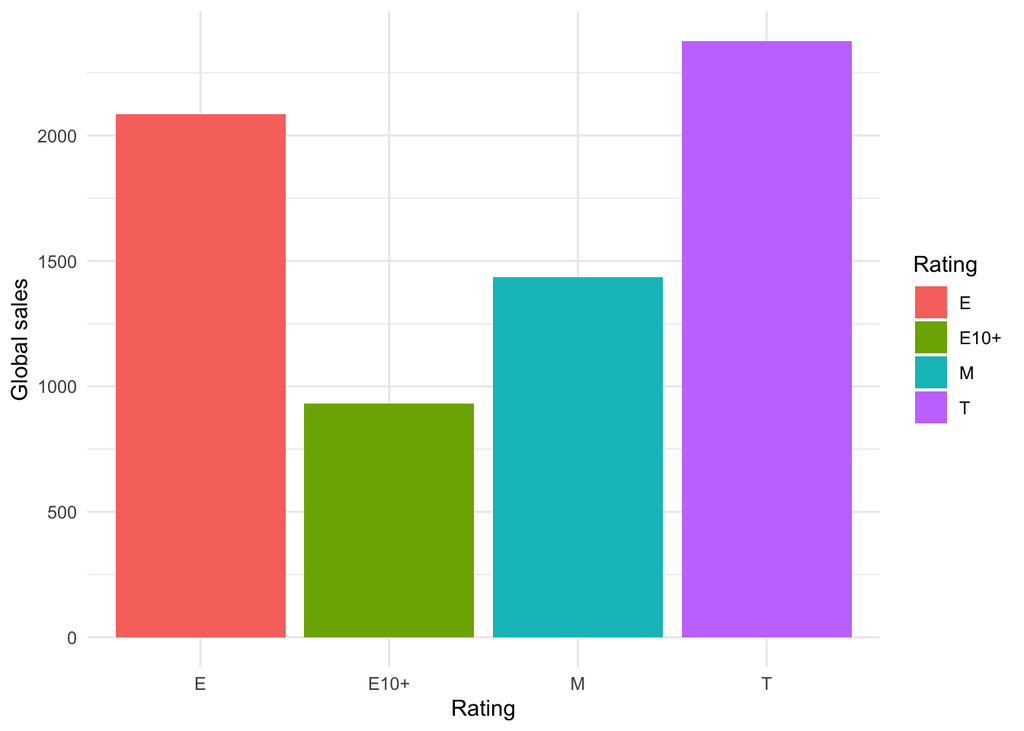

```r
rating_games_bar <- ggplot(vg_sales, aes(x=Rating,fill =Rating)) + geom_bar() +
      theme(text = element_text(size=10)) + xlab("Rating") + ylab("Global sales")+
  theme_minimal()
rating_games_bar
```

sales for each platform biggest sales from playstation 2 and xbox360

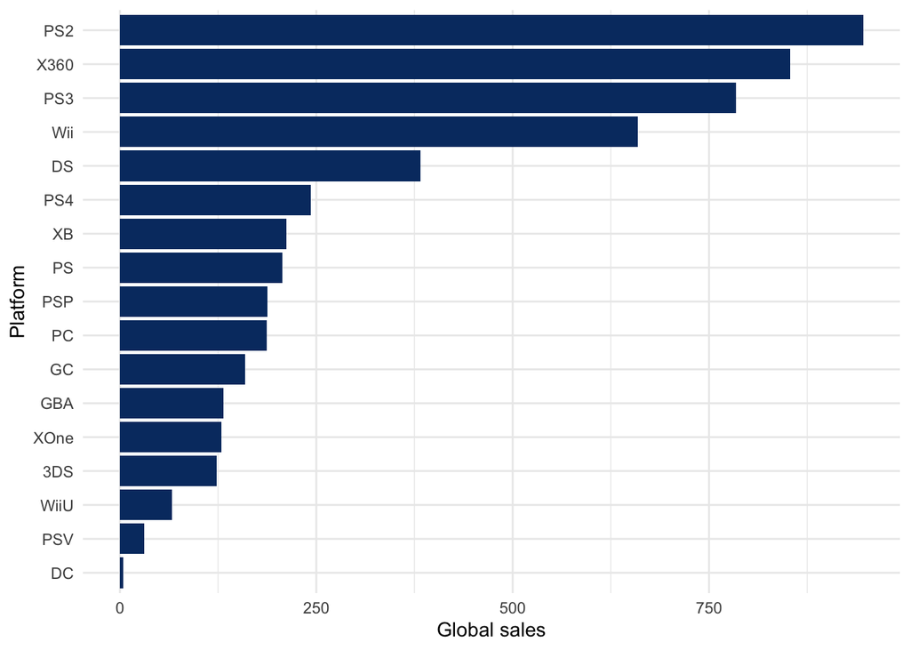

```r
vg_sales %>% group_by(Platform) %>%
  summarise(vg_sales = sum(Global_Sales)) %>% ggplot() +
  geom_bar(aes(reorder(Platform, vg_sales), vg_sales), stat = "identity",
           fill = "#063970") +
  xlab("Platform") + ylab("Global sales") +
  coord_flip() + theme_minimal()
```

sales by genre action, sports, shooters are the top genres

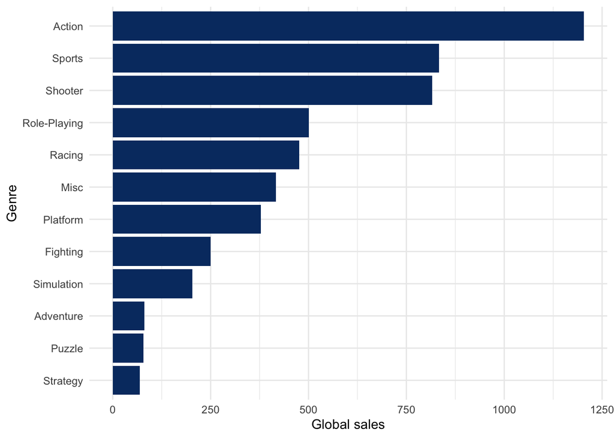

```r
vg_sales %>% group_by(Genre) %>%
  summarise(vg_sales = sum(Global_Sales)) %>% ggplot() +
  geom_bar(aes(reorder(Genre, vg_sales), vg_sales), stat = "identity",
           fill = "#063970") +
  xlab("Genre") + ylab("Global sales") +
  coord_flip() + theme_minimal()
```

sales in North America, Europe, Japan, Other north america had the highest overall sales from 1990-2016

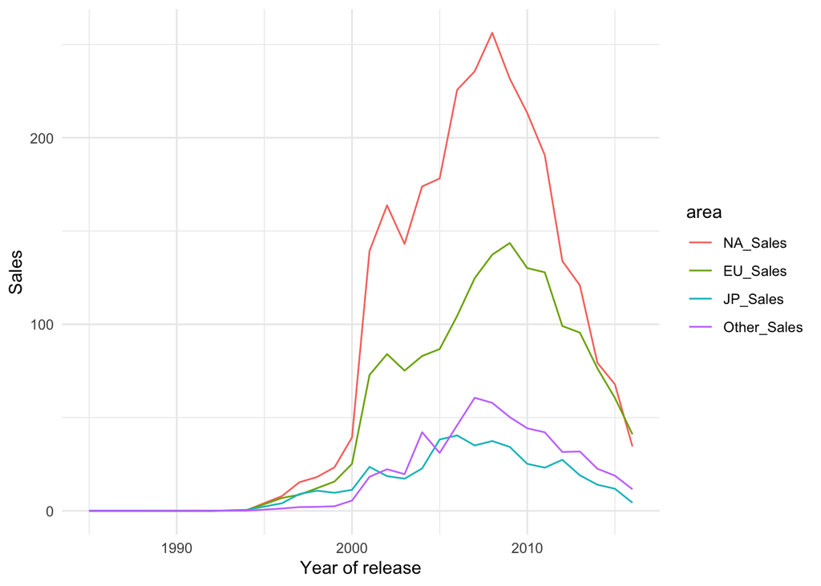

```r
vg_sales %>% gather(area, vg_sales, NA_Sales:Other_Sales,
                    factor_key = TRUE) %>%
  group_by(area,Year_of_Release) %>%
  summarise(vg_sales = sum(vg_sales)) %>% ggplot() +
  xlab("Year of release") + ylab("Sales") +
  geom_line(aes(Year_of_Release, vg_sales, group = area, color = area)) +
  theme_minimal() + theme(legend.text = element_text(size = 7),
                          legend.position = "bottom",
                          axis.text.x = element_text(angle = 90))+
  theme_minimal()
```

top 10 best selling games globally wii sports is the #1 game sold globally

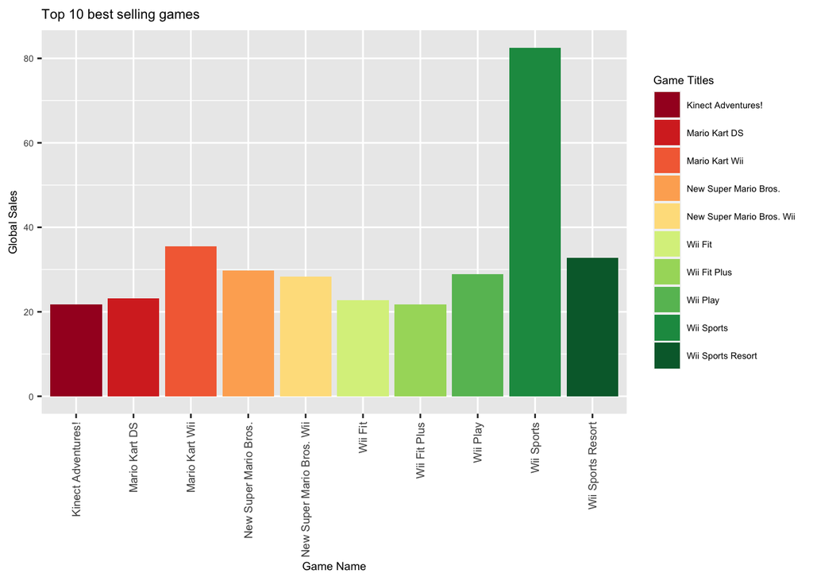

```r
vg_sales %>% select(Name,Global_Sales) %>% arrange(desc(Global_Sales))%>% head(10)%>%
  ggplot(aes(x=Name,y=Global_Sales,fill= Name))+geom_bar(stat="identity")+
  labs(x="Game Name",y="Global Sales",
       title="Top 10 best selling games")+
  theme(text = element_text(size=7),legend.position="right",
        axis.text.x=element_text(angle = 90,vjust = 0.5,hjust = 1,size=7))+
  scale_fill_brewer(name= "Game Titles",palette="RdYlGn")
```

bar plot of global sales extremely skewed plot, need to change x axis to log axis

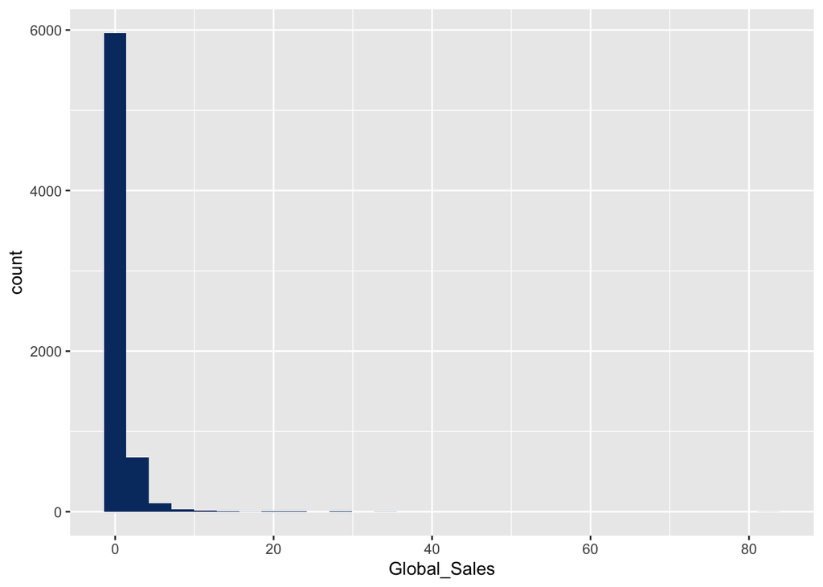

```r
ggplot(vg_sales) + geom_histogram(aes(Global_Sales), fill = "#063970")
```

fixing axis, better distribution - similar to gaussian distribution

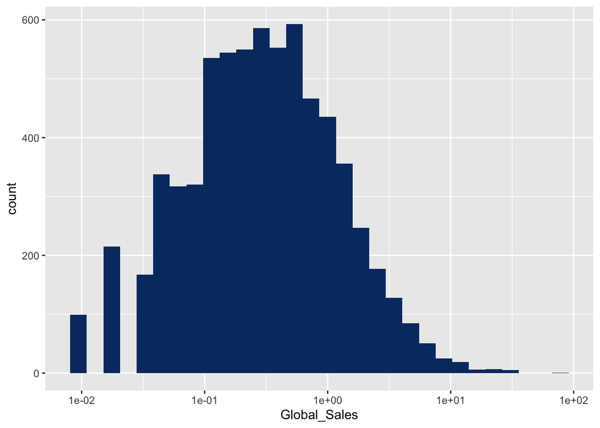

```r
ggplot(vg_sales) + geom_histogram(aes(Global_Sales), fill = "#063970") +
  scale_x_log10()
```

number of titles released each year there seems to be a peak within the data

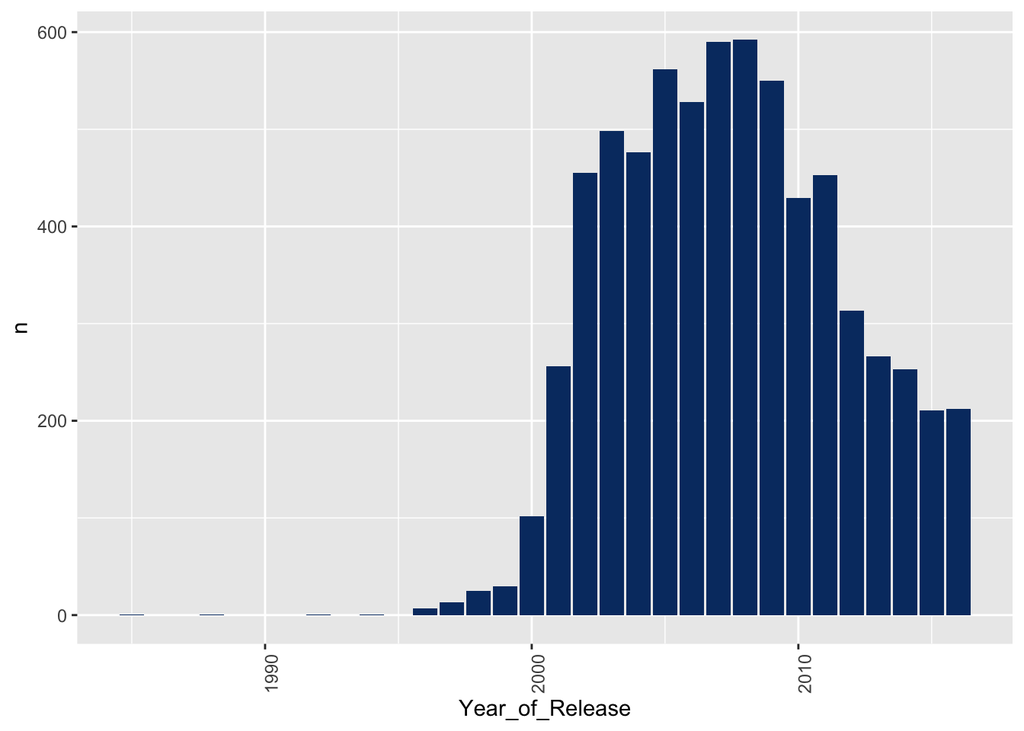

```r
vg_sales %>% group_by(Year_of_Release) %>%
  count() %>% ggplot() +
  geom_bar(aes(Year_of_Release, n), stat = "identity",
           fill = "#063970") + theme(axis.text.x = element_text(angle = 90))
```

sales each yr vs number of releases more revenue when more titles are released

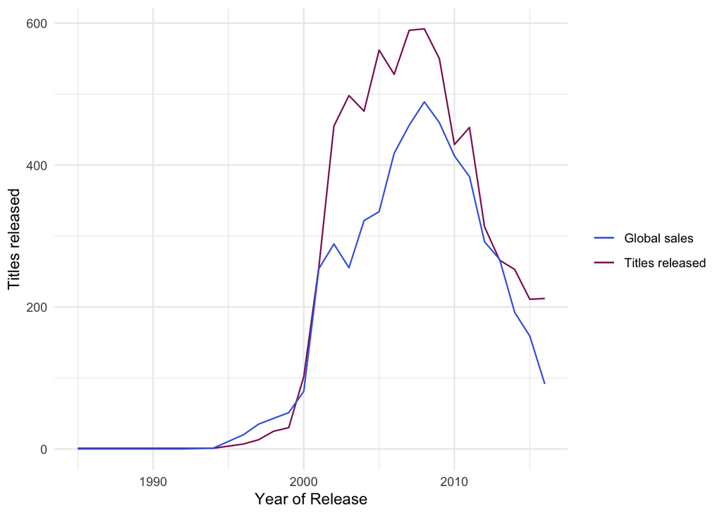

```r
color <- c("Titles released" = "maroon4", "Global sales" = "royalblue")
vg_sales %>% group_by(Year_of_Release) %>%
  summarise(vg_sales = sum(Global_Sales), count = n()) %>%
  ggplot() + xlab("Year of Release") + ylab("Titles released") +
  geom_line(aes(Year_of_Release, count, group = 1, color = "Titles released")) +
  geom_line(aes(Year_of_Release, vg_sales, group = 1, color = "Global sales")) +
  theme(axis.text.x = element_text(angle = 90), legend.position = "bottom") +
  scale_color_manual(name="",values = color) + theme_minimal()
```

combining platform by company - to simplify all these platforms

```r
vg_sales <- vg_sales %>% mutate(platform2 = case_when(
  Platform %in% c("Wii", "DS", "3DS", "WiiU", "GC", "GBA") ~ "Nintendo",
  Platform %in% c("X360", "XB", "XOne") ~ "XBox",
  Platform %in% c("PS3", "PS4", "PS2", "PS", "PSP", "PSV") ~ "PS",
  Platform == "PC" ~ "PC",
  Platform == "DC" ~ "Sega"
))
```

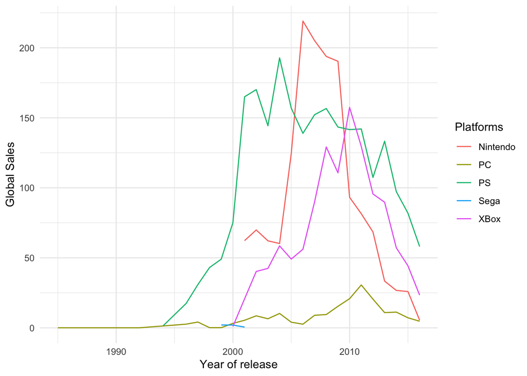

```r
vg_sales %>% group_by(platform2, Year_of_Release) %>%
  summarise(vg_sales = sum(Global_Sales)) %>%
  ggplot() + xlab("Year of release") + ylab("Global Sales") +
  geom_line(aes(Year_of_Release, vg_sales, group = platform2, color = platform2)) +
  theme(legend.text = element_text(size = 7),
        axis.text.x = element_text(angle = 90, hjust = 1,
                                   vjust = 0.5, size = 6))+
  theme_minimal() + labs(color='Platforms')
```

sales for each developer need to change individual bar colors

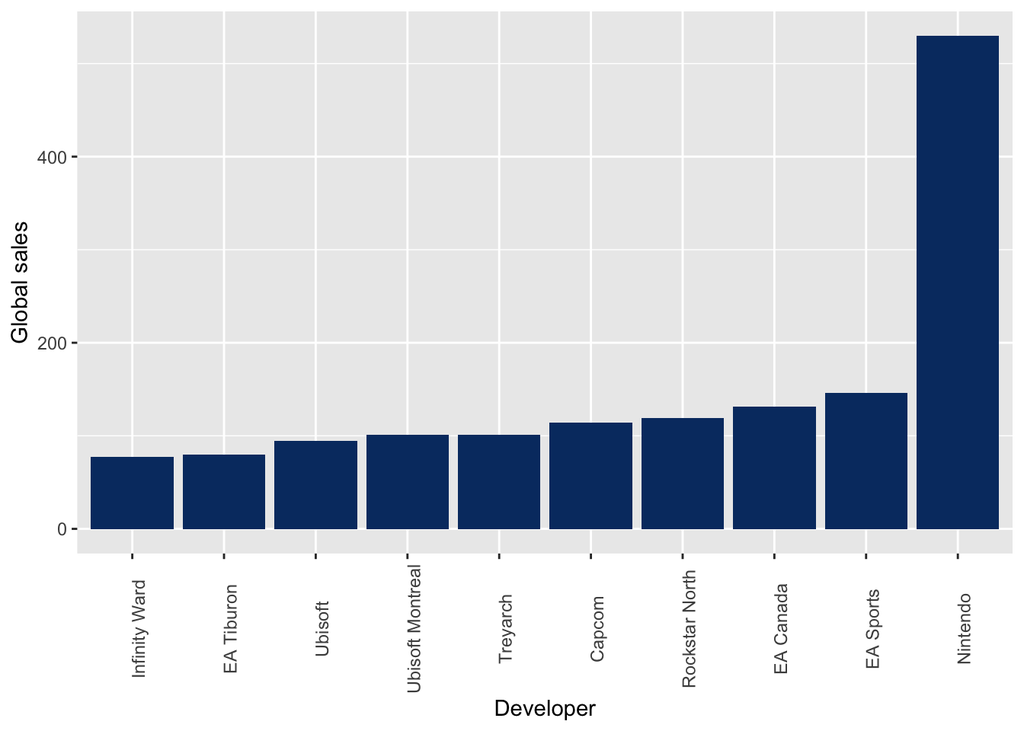

```r
vg_sales %>% group_by(Developer) %>%
  summarise(vg_sales = sum(Global_Sales)) %>%
  arrange(desc(vg_sales)) %>% slice(1:10) %>%
  ggplot() + xlab("Developer") + ylab("Global sales")+
  geom_bar(aes(reorder(Developer, vg_sales), vg_sales),
           stat = "identity", fill = "#063970") +
  theme(axis.text.x = element_text(angle = 90))
```

sales for each gaming genre need to change individual bar colors

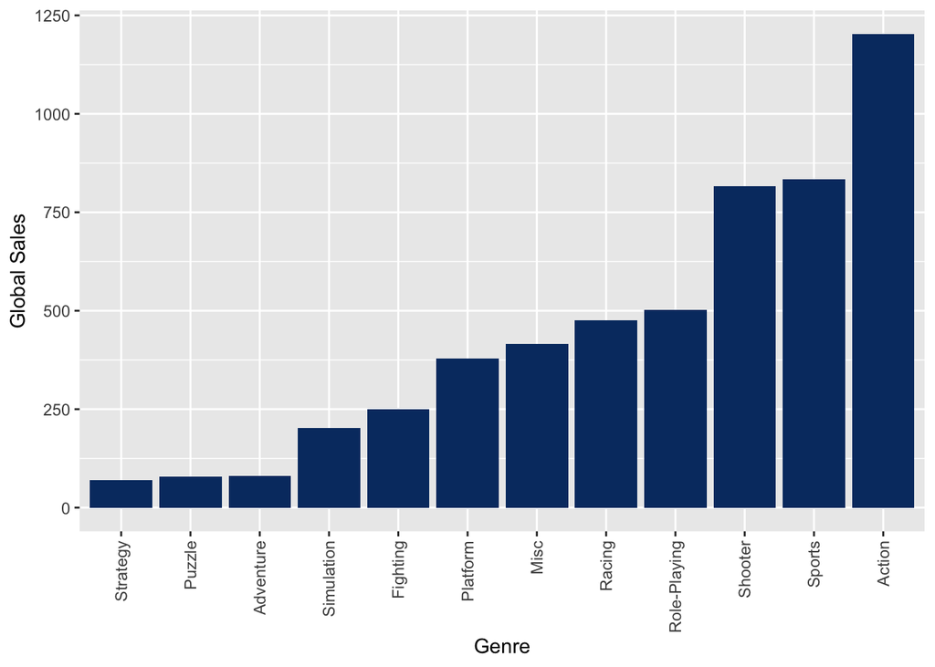

```r
vg_sales %>% group_by(Genre) %>%
  summarise(vg_sales = sum(Global_Sales)) %>%
  ggplot() +
  geom_bar(aes(reorder(Genre, vg_sales), vg_sales), stat = "identity",
           fill = "#063970") +
  ylab("Global Sales") + xlab("Genre") +
  theme(axis.text.x = element_text(angle = 90,
                                   hjust = 1, vjust = 0.5))
```

sales for each platform in each genre TOP TWO: xbox 360 - shooter ps3 - action

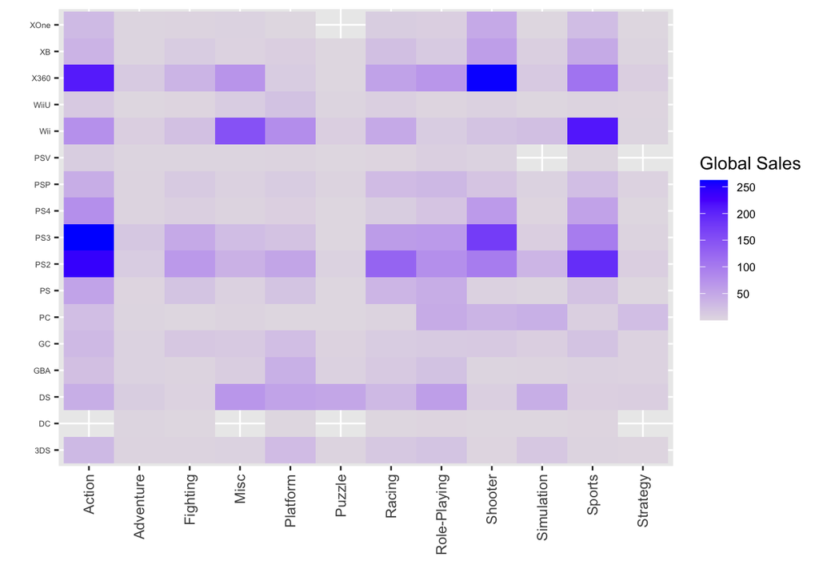

```r
vg_sales %>% group_by(Platform, Genre) %>%
  summarise(vg_sales = sum(Global_Sales)) %>%
  ggplot() + geom_raster(aes(Genre, Platform, fill = vg_sales)) +
  ylab("") + xlab("") +
  scale_fill_gradient(low = "#e4dee5", high = "blue") +
  theme(axis.text.x = element_text(angle = 90,
                                   vjust = 0.5, hjust = 1),
        axis.text.y = element_text(size = 5),
        legend.text = element_text(size = 7)) + labs(fill = "Global Sales")
```

# MODELS for results

Overall, the sales vary depending on the platform, release year, and developer

The top developers had the highest sales

publishers is categorical but has many values

```r
publishers_top <- (vg_sales %>% group_by(Publisher) %>%
                     summarise(vg_sales = sum(Global_Sales)) %>% arrange(desc(vg_sales)) %>%
                     top_n(10) %>% distinct(Publisher))$Publisher
```

developers is categorical but has many values

```r
developers_top <- (vg_sales %>% group_by(Developer) %>%
                     summarise(vg_sales = sum(Global_Sales)) %>% arrange(desc(vg_sales)) %>%
                     top_n(10) %>% distinct(Developer))$Developer
```

creating new variable for whether a game is created by a top developer/publisher - making it binary(0,1)

```r
vg_sales <- vg_sales %>%
  mutate(publisher_top = ifelse(Publisher %in% publishers_top, TRUE, FALSE),
         developer_top = ifelse(Developer %in% developers_top, TRUE, FALSE))
```

whether games are exclusively launched on a specific platform

```r
vg_sales <- vg_sales %>% group_by(Name) %>% mutate(num_of_platforms = n()) %>% ungroup(Name)
```

training and testing data sets

```r
set.seed(2000)
```

```r
test_index <- createDataPartition(vg_sales$Global_Sales, p = 0.9, list = FALSE)
train_set <- vg_sales[-test_index, ]
test_set <- vg_sales[test_index, ]
```

including categorical data as well

```r
totalData <- rbind(train_set, test_set)
for (f in 1:length(names(totalData))) {
  levels(train_set[, f]) <- levels(totalData[, f])
}
```

# creating RMSE function

```r
RMSE <- function(true_ratings, predicted_ratings){
  sqrt(mean((true_ratings - predicted_ratings)^2))
}
```

# linear regression model

base line model

```r
model_lm <- train(log(Global_Sales) ~ Critic_Score +
                     User_Score + Genre +
                     Year_of_Release + Critic_Count +
                     User_Count + Rating +
                     publisher_top + developer_top +
                     num_of_platforms, method = "lm", data = train_set)

# predicted values and RMSE
test_set$predicted_lm <- predict(model_lm, test_set)
rmse_results <- data.frame(Method = "Linear Regression",
                           RMSE = RMSE(log(test_set$Global_Sales), test_set$predicted_lm))
```

```r
summary(model_lm)
```

```
##
## Call:
## lm(formula = .outcome ~ ., data = dat)
##
## Residuals:
##     Min      1Q  Median      3Q     Max
## -3.5492 -0.6550  0.0338  0.7429  4.2654
##
## Coefficients:
##                       Estimate Std. Error t value Pr(>|t|)
## (Intercept)         98.1741865 24.1566937   4.064 5.41e-05 ***
## Critic_Score         0.0224176  0.0043304   5.177 3.00e-07 ***
## User_Score          -0.0077227  0.0035801  -2.157 0.031359 *
## GenreAdventure      -0.3436190  0.2611977  -1.316 0.188783
## GenreFighting        0.0901682  0.2012717   0.448 0.654306
## GenreMisc            0.4713842  0.2053026   2.296 0.021987 *
## GenrePlatform        0.1350117  0.2261371   0.597 0.550690
## GenrePuzzle         -0.5111645  0.4376765  -1.168 0.243268
## GenreRacing         -0.5712306  0.1746461  -3.271 0.001128 **
## `GenreRole-Playing` -0.1108867  0.1657300  -0.669 0.503679
## GenreShooter        -0.1578747  0.1460226  -1.081 0.280019
## GenreSimulation      0.3908662  0.2308355   1.693 0.090878 .
## GenreSports         -0.4196574  0.1762289  -2.381 0.017534 *
## GenreStrategy       -1.5527957  0.2499323  -6.213 9.23e-10 ***
## Year_of_Release     -0.0504934  0.0120083  -4.205 2.97e-05 ***
## Critic_Count         0.0305187  0.0028713  10.629  < 2e-16 ***
## User_Count           0.0003169  0.0001085   2.921 0.003607 **
## `RatingE10+`        -0.2095308  0.1479506  -1.416 0.157184
## RatingM             -0.6380651  0.1649593  -3.868 0.000121 ***
## RatingT             -0.4071647  0.1319754  -3.085 0.002120 **
## publisher_topTRUE    0.3950275  0.0936635   4.218 2.82e-05 ***
## developer_topTRUE    0.4678356  0.1379839   3.391 0.000739 ***
## num_of_platforms     0.0756197  0.0327896   2.306 0.021409 *
## ---
## Signif. codes:  0 '***' 0.001 '**' 0.01 '*' 0.05 '.' 0.1 ' ' 1
##
## Residual standard error: 1.102 on 658 degrees of freedom
## Multiple R-squared:  0.4077, Adjusted R-squared:  0.3879
## F-statistic: 20.59 on 22 and 658 DF,  p-value: < 2.2e-16
```

actual vs preds graph

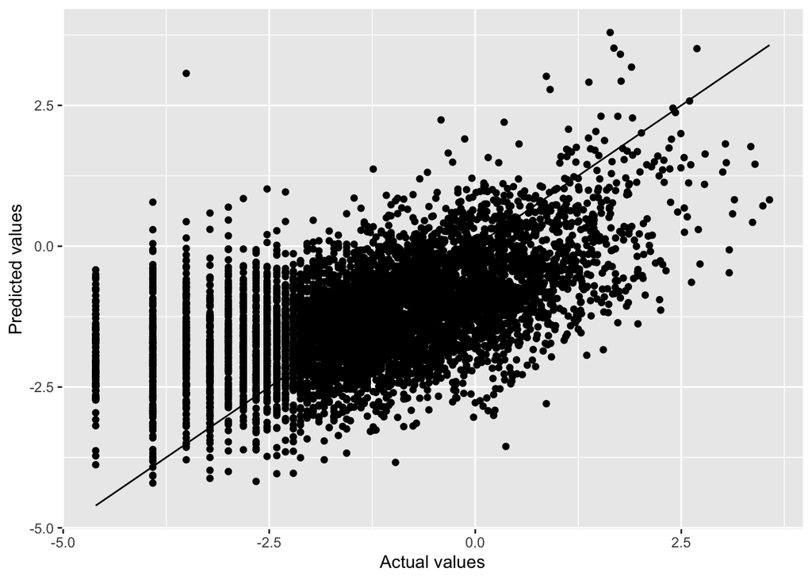

```r
ggplot(test_set) +
  geom_point(aes(log(Global_Sales), predicted_lm)) +
  geom_line(aes(log(Global_Sales), log(Global_Sales))) +
  xlab("Actual values") + ylab("Predicted values")
```

residual plot (error vs predicted) errors are largest for larger values of global sales - heteroskedacity present

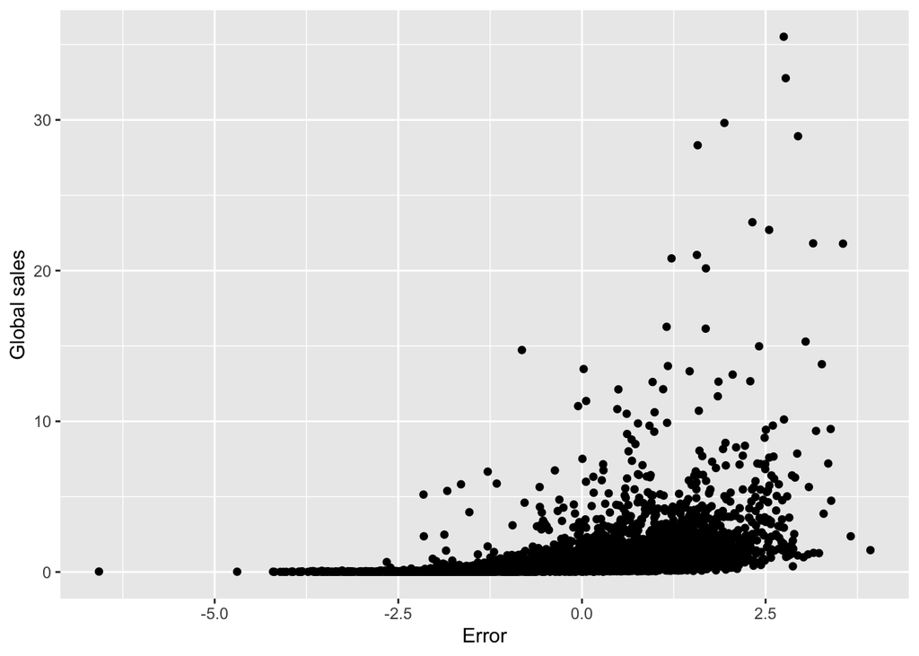

```r
ggplot(test_set) + geom_point(aes(log(Global_Sales) - predicted_lm, Global_Sales)) +
  xlab("Error") + ylab("Global sales")
```

# SVM Linear model

```r
model_svm_linear <- train(log(Global_Sales) ~ Critic_Score +
                     User_Score + Genre +
                     Year_of_Release +  Critic_Count +
                     User_Count + Rating +
                     publisher_top + developer_top +
                     num_of_platforms, method = "svmLinear",
                   data = train_set)

# predicted value and RMSE
test_set$predicted_svm_linear <- predict(model_svm_linear, test_set)
rmse_results <- rmse_results %>%
  add_row(Method = "SVM Linear",
          RMSE = RMSE(log(test_set$Global_Sales),
                      test_set$predicted_svm_linear))
```

summary of SVM linear model

```r
summary(model_svm_linear)
```

```
## Length  Class   Mode
##      1   ksvm     S4
```

# SVM poly

might take several minutes to run because it is more mathematically complex (polynomial function)

```r
model_svm_poly <- train(log(Global_Sales) ~ Critic_Score +
                     User_Score + Genre +
                     Year_of_Release + Critic_Count +
                     User_Count + Rating +
                     publisher_top + developer_top +
                     num_of_platforms, method = "svmPoly",
                   data = train_set)

# predicted value and RMSE
test_set$predicted_svm_poly <- predict(model_svm_poly, test_set)
rmse_results <- rmse_results %>%
  add_row(Method = "SVM Polynomial",
          RMSE = RMSE(log(test_set$Global_Sales),
                      test_set$predicted_svm_poly))
```

SVM poly model summary

```r
summary(model_svm_poly)
```

```
## Length  Class   Mode
##      1   ksvm     S4
```

# SVM radial

```r
model_svm_rad <- train(log(Global_Sales) ~ Critic_Score +
                          User_Score + Genre +
                          Year_of_Release +  Critic_Count +
                          User_Count + Rating +
                          publisher_top + developer_top +
                          num_of_platforms, method = "svmRadial",
                        data = train_set)

# predicted value and RMSE
test_set$predicted_svm_rad<- predict(model_svm_rad, test_set)
rmse_results <- rmse_results %>%
  add_row(Method = "SVM Radial",
          RMSE = RMSE(log(test_set$Global_Sales),
                      test_set$predicted_svm_rad))
```

SVM Radial summary

```r
summary(model_svm_rad)
```

```
## Length  Class   Mode
##      1   ksvm     S4
```

# L1 - lasso model

```r
model_l1 <- train(log(Global_Sales) ~ Critic_Score +
                    User_Score + Genre +
                    Year_of_Release +  Critic_Count +
                    User_Count + Rating +
                    publisher_top + developer_top +
                    num_of_platforms, method = "lasso", data = train_set)
# predicted values and RMSE
test_set$predicted_l1 <- predict(model_l1, test_set)
rmse_results <- rmse_results %>% add_row(Method = "L1 Lasso",
                                         RMSE = RMSE(log(test_set$Global_Sales),
                                                     test_set$predicted_l1))
```

summary of lasso

```r
summary(model_l1)
```

```
##             Length Class      Mode
## call          4    -none-     call
## actions      23    -none-     list
## allset       22    -none-     numeric
## beta.pure   506    -none-     numeric
## vn           22    -none-     character
## mu            1    -none-     numeric
## normx        22    -none-     numeric
## meanx        22    -none-     numeric
## lambda        1    -none-     numeric
## L1norm       23    -none-     numeric
## penalty      23    -none-     numeric
## df           23    -none-     numeric
## Cp           23    -none-     numeric
## sigma2        1    -none-     numeric
## xNames       22    -none-     character
## problemType   1    -none-     character
## tuneValue     1    data.frame list
## obsLevels     1    -none-     logical
## param         0    -none-     list
```

actual vs preds graph

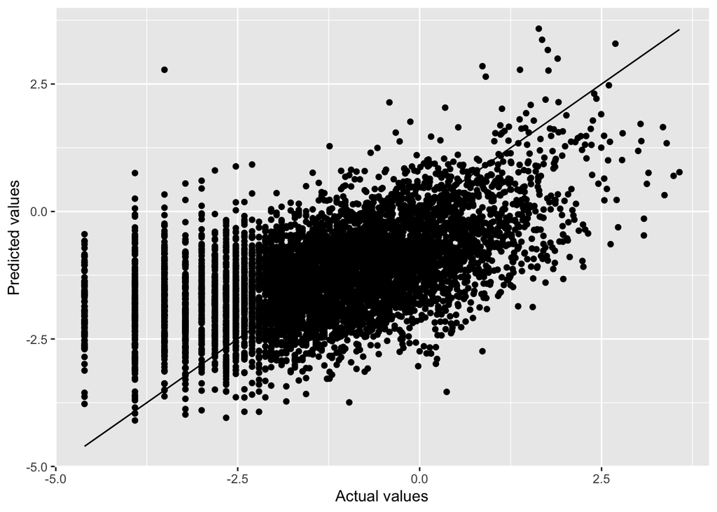

```r
ggplot(test_set) +
  geom_point(aes(log(Global_Sales), predicted_l1)) +
  geom_line(aes(log(Global_Sales), log(Global_Sales))) +
  xlab("Actual values") + ylab("Predicted values")
```

error vs sales

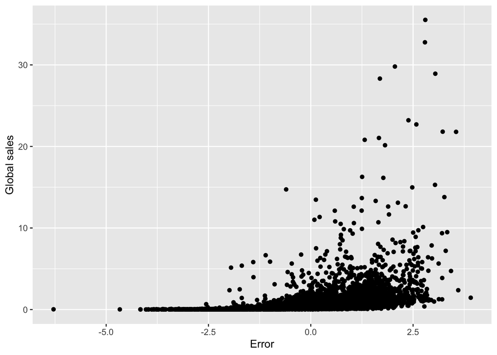

```r
ggplot(test_set) + geom_point(aes(log(Global_Sales) - predicted_l1, Global_Sales)) +
  xlab("Error") + ylab("Global sales")
```

# L2 - ridge model

```r
model_l2 <- train(log(Global_Sales) ~ Critic_Score +
                    User_Score + Genre +
                    Year_of_Release +  Critic_Count +
                    User_Count + Rating +
                    publisher_top + developer_top +
                    num_of_platforms, method = "ridge", data = train_set)

# predicted values and RMSE
test_set$predicted_l2 <- predict(model_l2, test_set)
rmse_results <- rmse_results %>% add_row (Method = "L2 Ridge",
                           RMSE = RMSE(log(test_set$Global_Sales), test_set$predicted_l2))
```

l2 model summary

```r
summary(model_l2)
```

```
##             Length Class      Mode
## call          4    -none-     call
## actions      23    -none-     list
## allset       22    -none-     numeric
## beta.pure   506    -none-     numeric
## vn           22    -none-     character
## mu            1    -none-     numeric
## normx        22    -none-     numeric
## meanx        22    -none-     numeric
## lambda        1    -none-     numeric
## L1norm       23    -none-     numeric
## penalty      23    -none-     numeric
## df           23    -none-     numeric
## Cp           23    -none-     numeric
## sigma2        1    -none-     numeric
## xNames       22    -none-     character
## problemType   1    -none-     character
## tuneValue     1    data.frame list
## obsLevels     1    -none-     logical
## param         0    -none-     list
```

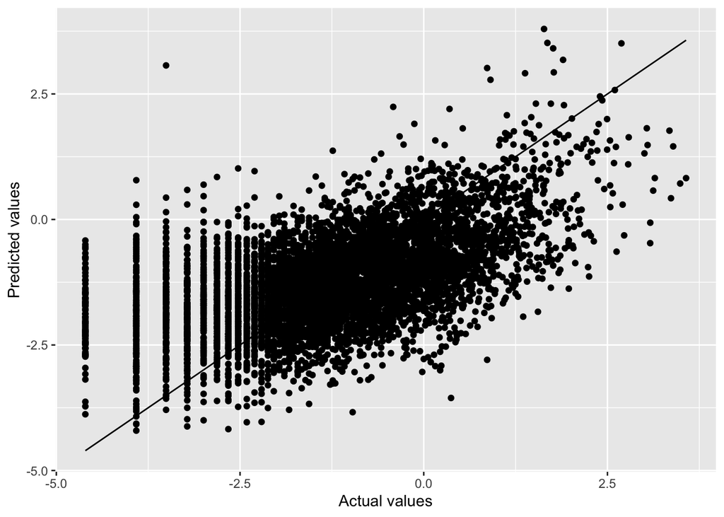

```r
ggplot(test_set) +
  geom_point(aes(log(Global_Sales), predicted_l2)) +
  geom_line(aes(log(Global_Sales), log(Global_Sales))) +
  xlab("Actual values") + ylab("Predicted values")
```

error vs sales

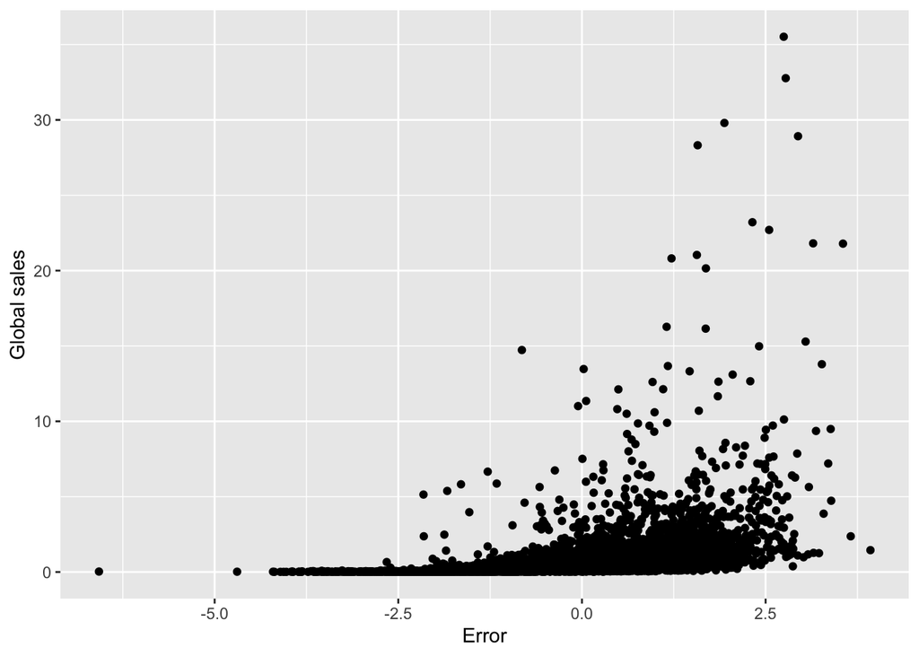

```r
ggplot(test_set) + geom_point(aes(log(Global_Sales) - predicted_l2, Global_Sales)) +
  xlab("Error") + ylab("Global sales")
```

# random forest

this one will also take a few minutes to run

```r
cntrl <- trainControl(method = "repeatedcv", number = 10,
                      repeats = 3)
tunegrid <- expand.grid(.mtry=c(1:5),
                        .min.node.size = seq(1, 5, 1),
                        .splitrule = c("extratrees", "variance"))
model_rf <- train(log(Global_Sales) ~ Critic_Score +
                    User_Score + Genre +
                    Year_of_Release + Critic_Count +
                    User_Count + Rating +
                    publisher_top + developer_top +
                    num_of_platforms, data = train_set,
                  method = "ranger", trControl = cntrl,
                  tuneGrid = tunegrid)

# predicted and RMSE
test_set$predicted_rf <- predict(model_rf, test_set)
rmse_results <- rmse_results %>% add_row(Method = "Random Forest",
                RMSE = RMSE(log(test_set$Global_Sales), test_set$predicted_rf))
```

actual vs preds

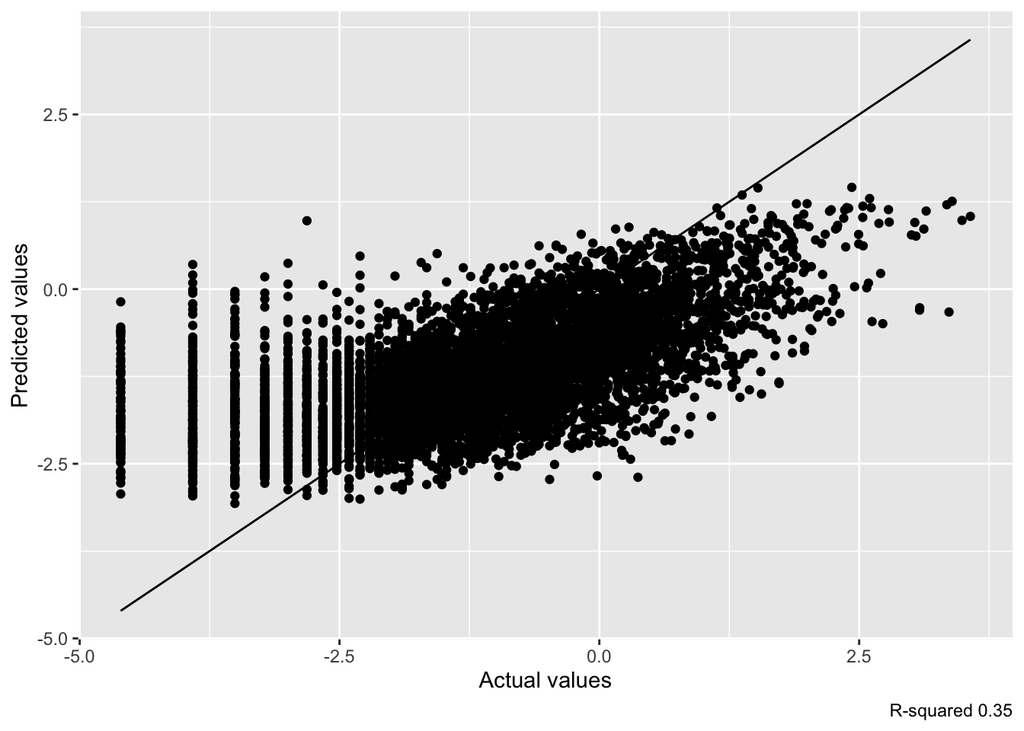

```r
ggplot(test_set) +
  geom_point(aes(log(Global_Sales), predicted_rf)) +
  geom_line(aes(log(Global_Sales), log(Global_Sales))) +
  xlab("Actual values") + ylab("Predicted values") +
  labs(caption =
         paste("R-squared",
               format(model_rf$finalModel$r.squared,
                      digits = 2)))
```

error vs global

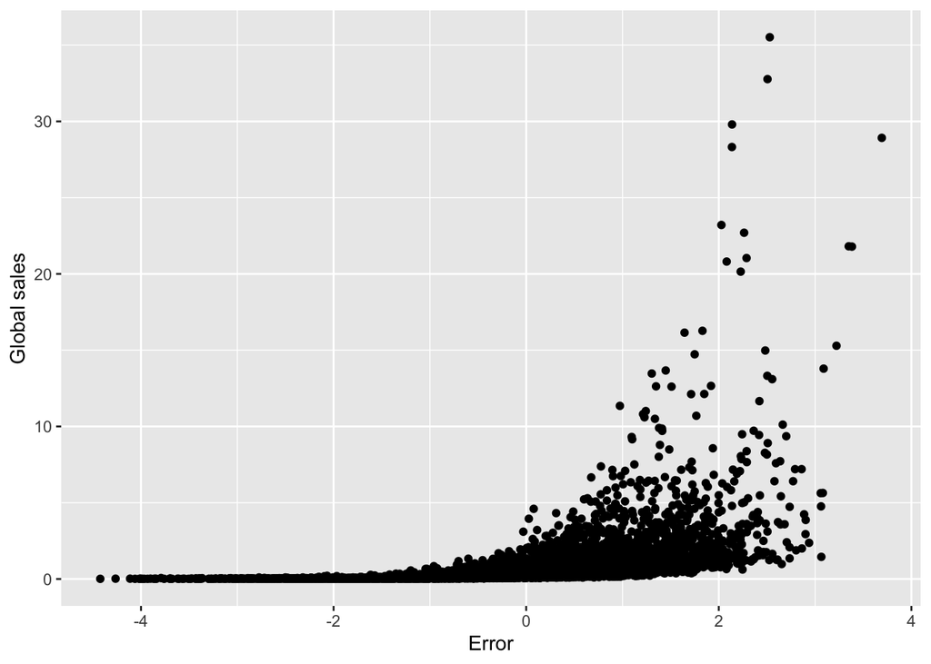

```r
ggplot(test_set) + geom_point(aes(log(Global_Sales) - predicted_rf, Global_Sales)) +
  xlab("Error") + ylab("Global sales")
```

compare the RMSE values of each model

```r
rmse_results
```

```
##              Method     RMSE
## 1 Linear Regression 1.165805
## 2        SVM Linear 1.193608
## 3    SVM Polynomial 1.173235
## 4        SVM Radial 1.183304
## 5          L1 Lasso 1.159685
## 6          L2 Ridge 1.165798
## 7     Random Forest 1.092527
```

# plotting and comparing all the models RMSE’s

# random forest did best!

```r
rmse_plot <- ggplot(rmse_results, aes(x=RMSE,y=Method, fill = Method))+geom_bar(stat="identity")+
  xlab("RMSE") + ylab("Model Type")
theme(text = element_text(size=10),
      legend.position="right",
      axis.text.x=element_text(angle = 90,vjust = 0.5,hjust = 1,size=8))
```

[output not shown]

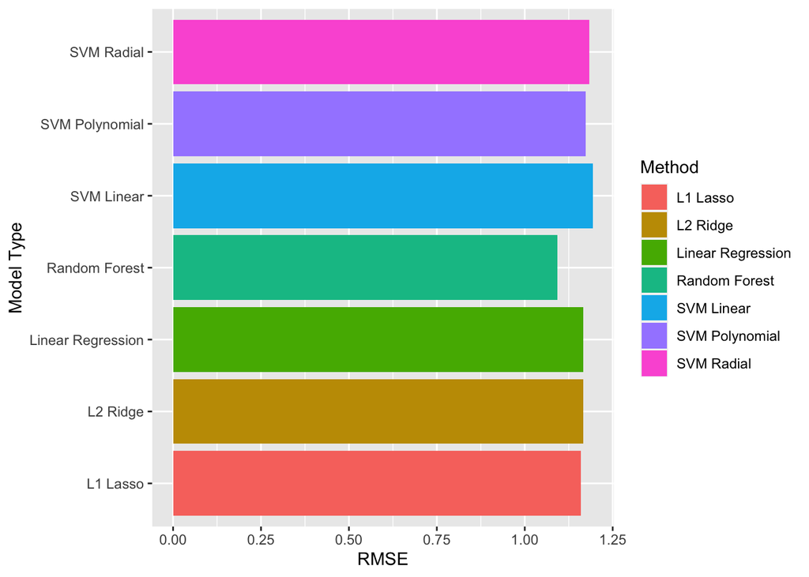

```r
rmse_plot
```